# A Musical Portrait

### How many Beats per Minute (BPM): Checking my Tempo

Next, I would like to see how the tempo of my musical preference has evolved. As someone who loves high-energy sounds as well as mellow tunes, I wonder how my taste has been influenced by these preferences over time. I can achieve this by using a histogram to measure changes over time across the different eras.

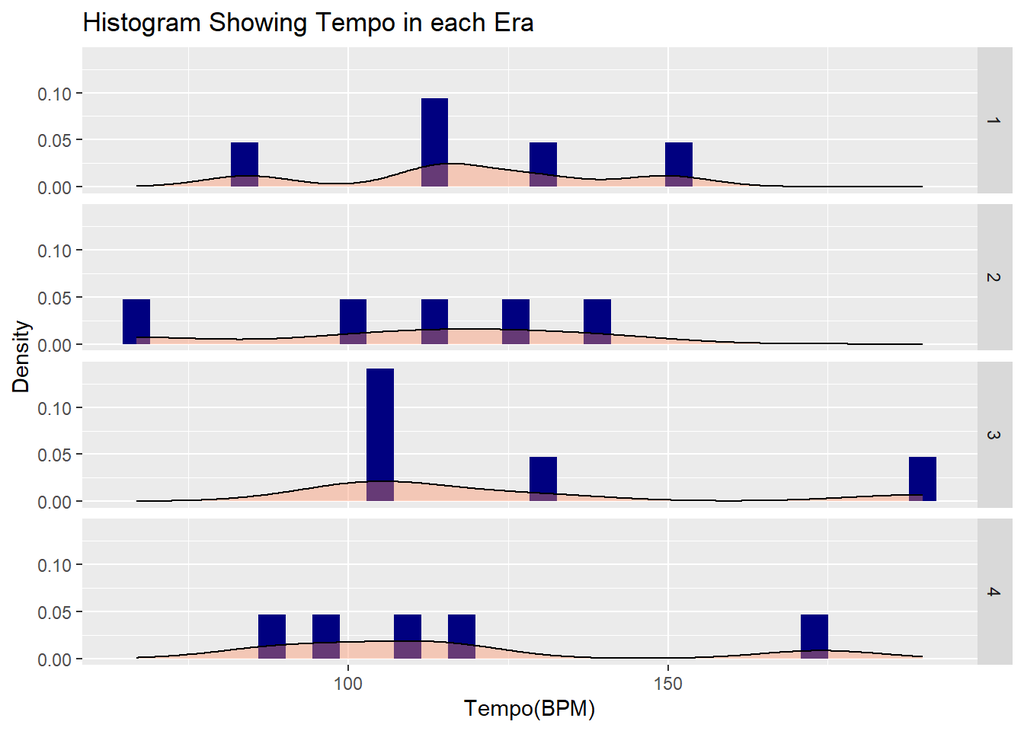

```r
ggplot(Musical_ME, aes(x=Tempo)) +
  geom_histogram(aes(y = after_stat(density)), fill = "navy") +
  geom_density(fill="#ff9166", alpha = 0.4) +
  facet_grid(Era~.) +
  labs(title="Histogram Showing Tempo in each Era", x = "Tempo(BPM)", y = "Density")
```

Here, we can see that overall, most of my songs tend to sit around 100 - 125 BPM, but I also have strong outliers. Comparing my first era to my third era, the music in the first is more centred around 100-130 BPM, and in my third era, there is a strong cluster around 110 BPM, however, there is also a unique outlier near ~ 190 BPM.

### Am I more sad & angry or joyful & peaceful: Tracking where my music lies between Energy vs. Valence

Now, I would like to see how my taste varies along the matrix between valence and energy. A scatterplot would be appropriate here:

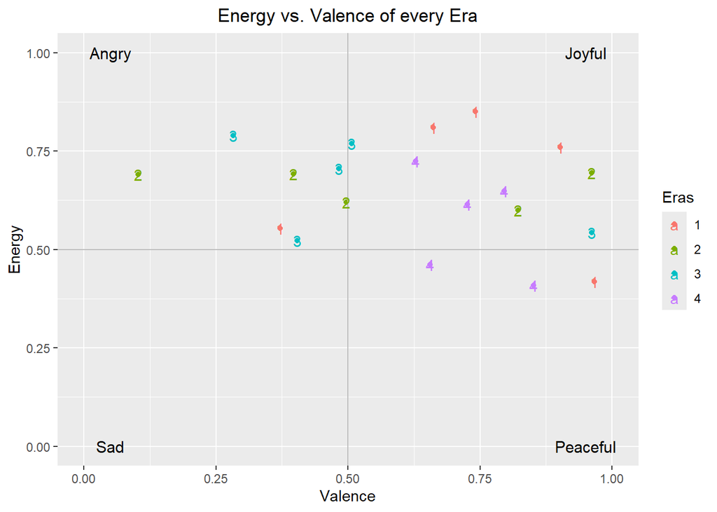

```r
library(ggplot2)


ggplot(Musical_ME, aes(x= Valence, y = Energy, color = Era )) +
  geom_point() +
  xlim(0,1) +
  ylim(0,1) +
  labs(color = "Eras", title = "Energy vs. Valence of every Era") +
  theme(plot.title = element_text(hjust = 0.5)) +
  geom_hline(yintercept = 0.5, color = "grey") +
  geom_vline(xintercept = 0.5, color = "grey") +
  annotate("text", x = 0.05, y = 1, label = "Angry", size = 4) +
  annotate("text", x = 0.95, y = 1, label = "Joyful", size = 4) +
  annotate("text", x = 0.05, y = 0, label = "Sad", size = 4) +
  annotate("text", x = 0.95, y = 0, label = "Peaceful", size = 4) +
  geom_text(data = Musical_ME, aes(label = Era) )
```

This shows that my musical taste is more spread out between joy, anger, and peace. My musical preferences from my second and third era are quite angry, while my fourth era lies more evenly between joyful and peaceful.

### Could there be a correlation?

Finally, I thought it’d be interesting to see if there is any relationship between acousticness in my musical taste and danceability. These two categories may seem to contradict each other due to their compositional elements. On one hand, acousticness distinguishes whether a song is produced primarily with natural, non-electronic instruments or relies on electronic or synthetic amplification, while danceability is influenced by metrics like beat strength and rhythmic stability. So, seeing how natural or synthetic sound relates to rhythmic stability and beat strength would be insightful. I will be using a scatterplot to see if there is a correlation between both variables.

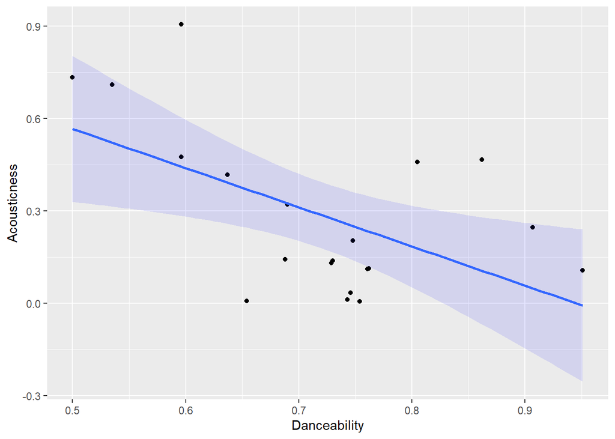

```r
library(ggplot2)

ggplot(Musical_ME, aes(x = Danceability, y = Acousticness)) +
  geom_point() +
  geom_smooth(method = "lm", alpha = 0.1, fill = "blue")
```

Surprisingly, there is a correlation between both, although it is not strong. From the scatterplot, we can see a moderate negative relationship between acousticness and danceability, implying that the more acoustic a song is, the less danceable it is likely to be.

### A taste of my sounds: Highs and Lows

It would be interesting to find out my most positive and most negative songs. So, you can immerse yourself in what a high-energy or mellow day sounds like to me.

#### Sunshine Days: Most Positive Songs

```r
library (dplyr)

Musical_ME |> slice_max(Valence, n =3) |> dplyr::select(Song, Artist, Release_Year, Era, Valence, Energy) |> knitr::kable(digits = 2)
```

| Song | Artist | Release_Year | Era | Valence | Energy |
| --- | --- | --- | --- | --- | --- |
| Pass The Dutchie | Musical Youth | 1982 | 1 | 0.97 | 0.42 |
| Beautiful | Snoop Dogg & Pharrell Williams | 2003 | 2 | 0.96 | 0.70 |
| Wo!! | Olamide | 2017 | 3 | 0.96 | 0.54 |

#### Mellow Days: Most Negative Songs

```r
library (dplyr)

Musical_ME |> slice_min(Valence, n =3) |> dplyr::select(Song, Artist, Release_Year, Era, Valence, Energy) |> knitr::kable(digits = 2)
```

| Song | Artist | Release_Year | Era | Valence | Energy |
| --- | --- | --- | --- | --- | --- |
| Young Forever | Jay-Z & Mr. Hudson | 2009 | 2 | 0.10 | 0.69 |
| Jealous | Fireboy DML | 2019 | 3 | 0.28 | 0.79 |
| Chiquitita | ABBA | 1979 | 1 | 0.37 | 0.55 |

Interestingly, my most positive and negative songs are spread equally between my first, second and third era, ranging from when I was a baby to being a teenager. Likewise, comparing these eras to my most recent, they were more influenced by the people around me - my parents and my peers. As I have grown older, I found more confidence in my musical taste, and confidently choose the songs I know and love, which makes them more complex than really joyful or really sober music.

### Time for a listening experience!

I have decided to include my favorite and least favorite song from this list to give you an idea of what I currently enjoy!

#### Current Favorite Tune

[video not shown]

#### Current Least Favorite Tune

[video not shown]

## Conclusion

Ultimately, I think this research is a strong representation of my musical taste and evolution. It explains why I can have a smooth, slow-paced tune like When I’m In Your Arms by Cleo Sol alongside a fast and loud tune like Wo! by Olamide. It’s an ode to the fact that we are all complex beings, and no one artist can fully exemplify our taste in music; only we can.